# Analysis of repated measures data in RStan

Marco Munda [marco.munda@pharmalex.com]

September 01, 2018

# Introduction

This repeated measures example is used in Littell et al. (2006, Chapter 5) to illustrate the analysis of repeated measures data in SAS proc mixed (frequentist).

Here we re-examine this example in the Bayesian framework using RStan.

In addition to the modelling itself, we further show

- how to make inference on the primary effect based on a probability of success, and
- how to predict the longitudinal profile of a future patient,

two difficult (if not impossible) tasks from a frequentist perspective.

# Data

Three drugs (A = standard drug, C = test drug, P = placebo) are examined for their effects on pulmonary function in asthma patients. 24 patients received *each* of the three drugs at random and the FEV1 measure (forced expiratory volume in one second) was taken prior to administration of the drug (baseline) and every hour for 8 hours following administration.

The main interest here lies on how differences between treatment means change over time.

The first few lines of the dataset appear below. The full dataset can be downloaded from the [book’s website](https://www.sas.com/store/books/categories/usage-and-reference/sas-for-mixed-models-second-edition/prodBK_59882_en.html).

| patient | drug | basefev1 | fev11h | fev12h | fev13h | fev14h | fev15h | fev16h | fev17h | fev18h |
| --- | --- | --- | --- | --- | --- | --- | --- | --- | --- | --- |
| 201 | a | 2.46 | 2.68 | 2.76 | 2.50 | 2.30 | 2.14 | 2.40 | 2.33 | 2.20 |
| 201 | c | 2.30 | 3.41 | 3.48 | 3.41 | 3.49 | 3.33 | 3.20 | 3.07 | 3.15 |
| 201 | p | 2.14 | 2.36 | 2.36 | 2.28 | 2.35 | 2.31 | 2.62 | 2.12 | 2.42 |
| 202 | a | 3.50 | 3.95 | 3.65 | 2.93 | 2.53 | 3.04 | 3.37 | 3.14 | 2.62 |
| 202 | c | 2.91 | 3.92 | 4.02 | 4.04 | 3.64 | 3.29 | 3.10 | 2.70 | 2.69 |
| 202 | p | 3.37 | 3.03 | 3.02 | 3.19 | 2.98 | 3.01 | 2.75 | 2.70 | 2.84 |

The data are processed more conveniently when converted from a wide format to a long format.

```r
data <- data %>%
  gather(key = time, value = fev1, fev11h:fev18h) %>%
  mutate(time = gsub("fev1", "", time)) %>%
  arrange(patient, drug, time)
```

| patient | drug | basefev1 | time | fev1 |
| --- | --- | --- | --- | --- |
| 201 | a | 2.46 | 1h | 2.68 |
| 201 | a | 2.46 | 2h | 2.76 |
| 201 | a | 2.46 | 3h | 2.50 |
| 201 | a | 2.46 | 4h | 2.30 |
| 201 | a | 2.46 | 5h | 2.14 |
| 201 | a | 2.46 | 6h | 2.40 |
| 201 | a | 2.46 | 7h | 2.33 |
| 201 | a | 2.46 | 8h | 2.20 |
| 201 | c | 2.30 | 1h | 3.41 |

For modelling purposes, ‘drug = p’ and ‘time = 1h’ are set as reference categories (dummy coding).

```r
data <- data %>%
  mutate(drug = relevel(factor(data$drug), ref = "p"),
         time = relevel(factor(data$time), ref = "1h"))
```

# Data visualisation

Patient’s profiles are shown below.

Some profiles tend to be higher or lower consistently across the three drugs, thus indicating the presence of a patient effect. Further, for a given patient on a given drug, consecutive FEV1 measures are more correlated than measures further apart in time. To account for this, the data will be processed in blocks of temporally correlated data.

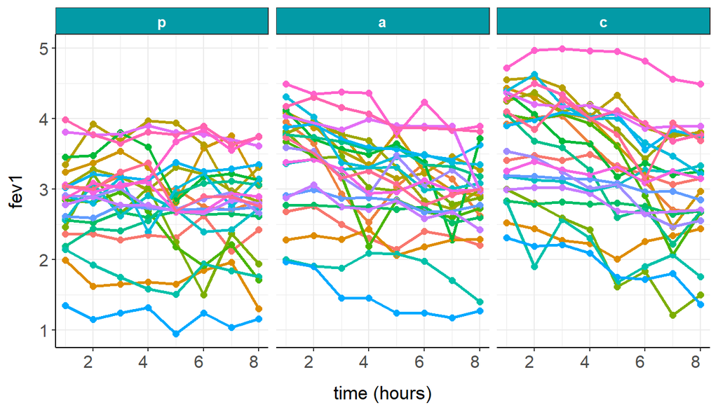

# Data preparation for Stan

To feed stan, the data are re-arranged in a list:

- `N` = total number of observations,
- `Npat` = number of patients,
- `p` = number of regression parameters,
- `X` = design matrix of the explanatory variables,
- `Z` = design matrix of the patient effects,
- `y` = response variable,
- `Nblocks` = number of blocks of temporally correlated data,
- `first` = vector with indices of the first record per block,
- `last` = vector with indices of the last record per block,
- `n` = vector with numbers of records per block,
- `maxn` = maximum number of records in a block.

```r
X        <- model.matrix(~ basefev1 + drug + time + time:drug, data = data)
Z        <- model.matrix(~ -1 + patient, data = data)
block    <- paste0(data$patient, data$drug)
Nblocks  <- length(unique(block))
first    <- sapply(split(1:nrow(data), block), function(x) head(x, 1))
last     <- sapply(split(1:nrow(data), block), function(x) tail(x, 1))
n        <- last - first + 1

datalist <- list(N        = nrow(data),
                 Npat     = length(unique(data$patient)),
                 p        = ncol(X),
                 X        = X,
                 Z        = Z,
                 y        = data$fev1,
                 Nblocks  = Nblocks,
                 first    = first,
                 last     = last,
                 n        = n,
                 maxn     = max(n))
```

The joint posterior distribution of the estimated marginal means (EMMs) for each drug over time, the quantities of interest in the case study, can be obtained by linear combinations of the model coefficients after the model is fitted. Less tediously, all EMMs can be generated at once in the ‘generated quantities’ Stan block. To this end, ‘datalist’ is appended with the design matrix of all combinations of drug and time (using the overall average FEV1 level at baseline).

```r
datanew  <- expand.grid(
  basefev1 = mean(data$basefev1),
  drug     = relevel(factor(c("p", "a", "c")), ref = "p"),
  time     = relevel(factor(paste0(1:8, "h")), ref = "1h"))

Nnew     <- nrow(datanew)
Xnew     <- model.matrix(~ basefev1 + drug + time + time:drug, data = datanew)

datalist <- c(datalist, list(Nnew = Nnew, Xnew = Xnew))
```

# Stan model

The Stan model is presented below.

The data are processed by blocks of temporally correlated data. Within a block, the multivariate normal distribution, ‘*multi_normal(mu, Sigma)*’, is used.

The mean is dictacted by the linear model, $\text{E}(Y) = X \beta + Z b$, where $X$ denotes the design matrix of the explanatory variables (intercept, baseline measure, drug, time, drug*time interaction) and where $Z$ denotes the design matrix of the patient effects.

The covariance matrix specifies the covariance structure between the repeated measures within a block. Many different choices can be made (Littell, Pendergast, and Natarajan 2000). Following the original case study (Littell et al. 2006), the AR(1) structure is chosen, i.e.
$$\text{Cov}(y_{ijk}, y_{ijk^\prime}) = \sigma^2 \, \rho^{|k-k^\prime|} \qquad
(0 < \rho < 1)$$
($i$, $j$, and $k$ indexing drugs, patients, and visits, respectively).

In words, the variance is the same at any time point ($\sigma^2$) while the correlation between repeated measures declines with increasing distance in time ($\rho$, $\rho^2$, $\rho^3$, …).

When the repeated measures are equally spaced, the AR(1) structure is the most popular choice. Further, the AR(1) variance component and the between-patient variance component are identifiable. This is not true for all covariance structures (e.g., compound symmetry or unstructured); at least in the absence of strong priors. Of note, it could be computationally more advantageous under the AR(1) structure to parametrise the multivariate normal distribution in terms of the precision matrix $\Omega = \Sigma^{-1}$, ‘*multi_normal_prec(mu, Omega)*’, because then $\Omega$ is tridiagonal (Sutradhar and Kumar 2003).

The AR(1) covariance matrix is built in the ‘transformed parameters’ block.

```r
modelString <- "

  data {
    int N;                        // total number of observations
    int Npat;                     // number of patients
    int p;                        // number of regression parameters
    matrix[N, p] X;               // design matrix of the explanatory variables
    matrix[N, Npat] Z;            // design matrix of the patient effects
    vector[N] y;                  // response variable
    int Nblocks;                  // nb of blocks of temporally correlated data
    int first[Nblocks];           // index of the first record per block
    int last[Nblocks];            // index of the last record per block
    int n[Nblocks];               // number of records per block
    int maxn;                     // maximum number of records in a block
    int Nnew;                     // number of EMMs
    matrix[Nnew, p] Xnew;         // design matrix of the EMMs
  }

  parameters {
    vector[p] beta;               // regression parameters
    vector[Npat] b;               // patient effects
    real<lower=0> sig2_b;         // patient-to-patient variance
    real<lower=0> sig2;           // residual variance
    real<lower=0,upper=1> rho;    // residual correlation parameter
  }

  transformed parameters {
    matrix[maxn, maxn] Sigma;     // residual covariance matrix
    for (row in 1:maxn) {
      for (col in 1:maxn) {
        Sigma[row, col] = sig2 * rho^(abs(col - row));
      }
    }
  }

  model {
    vector[N] eta;                // linear predictor
    b ~ normal(0, sqrt(sig2_b));  // patient effects
    eta = X * beta + Z * b;
    for (i in 1:Nblocks) {
      target += multi_normal_lpdf(
        y[first[i]:last[i]] |
        eta[first[i]:last[i]],
        Sigma[1:n[i], 1:n[i]]);
    }
  }

  generated quantities {
    vector[Nnew] EMMs;
    EMMs = Xnew * beta;
  }

"
```

The Stan code can easily be adapted to other covariance structures. For example, to adapt the Stan code to the homogeneous unstructured covariance model (without patient effect for identifiability reasons),
$$\text{Cov}(y_{ijk}, y_{ijk^\prime}) = \sigma^2 \, \rho_{kk^\prime} \qquad
(-1 < \rho < 1)$$
the ‘parameters’ and ‘transformed parameters’ blocks become

```r
"
  parameters {
      vector[p] beta;             // regression parameters
      real<lower=0> sig2;         // residual variance
      corr_matrix[maxn] R;        // unstructured residual correlation matrix
    }

  transformed parameters {
    matrix[maxn, maxn] Sigma;     // residual covariance matrix
    Sigma = quad_form_diag(R, rep_vector(sqrt(sig2), maxn));
  }
"
```

The function ‘*quad_form_diag*’ is used to convert a correlation matrix into a covariance matrix. ‘*quad_form_diag*’ is defined so that ‘*quad_form_diag(Sigma, tau)*’ is equivalent to ‘*diag_matrix(tau) $\times$ Sigma $\times$ diag_matrix(tau)*’, where ‘*diag_matrix(tau)*’ returns the matrix with ‘*tau*’ on the diagonal and zeroes off diagonal.

To facilitate the comparison with the original frequentist analysis, flat priors are used. It is worth noting here that priors on (the lower Cholesky factors of) correlation matrices can be assigned in Stan by means of the [LKJ distribution](http://stla.github.io/stlapblog/posts/StanLKJprior.html).

# Model fitting

```r
stanDso <- stan_model(model_code = modelString)

stanfit <- sampling(object  = stanDso,
                    data    = datalist,
                    chains  = 4,
                    iter    = 3000,
                    warmup  = 1000,
                    thin    = 4)

# EXTRACT THE POSTERIOR CHAINS
chains  <- data.frame(rstan::extract(stanfit))
Nchains <- nrow(chains)
```

The trace plots show good mixing of the 4 chains.

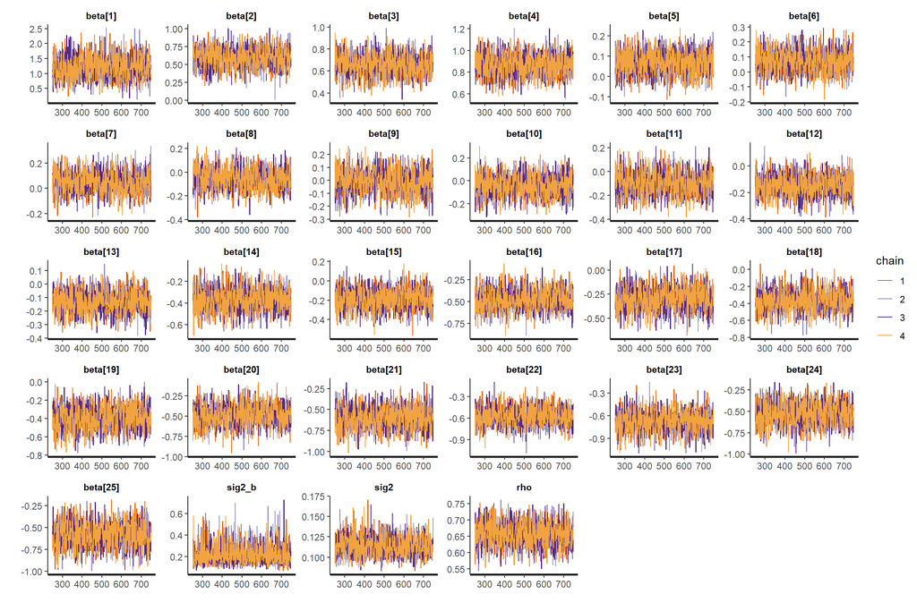

```r
traceplot(stanfit, pars = c("beta", "sig2_b", "sig2", "rho"))
```

# Posterior distributions

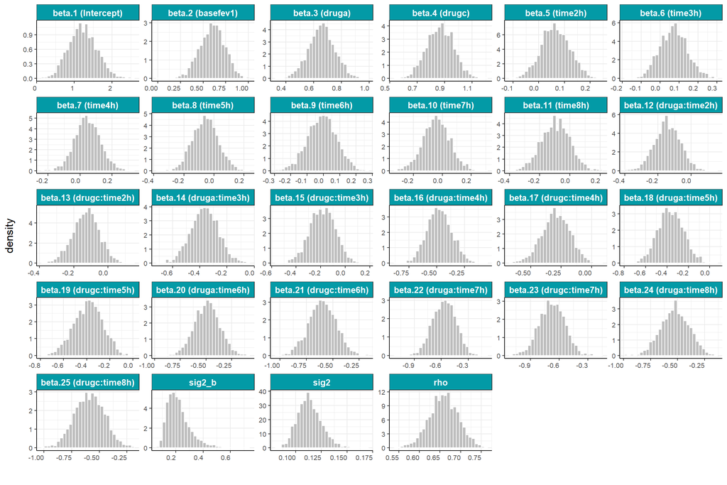

# Estimated marginal means (EMMs)

The FEV1 EMMs for each drug over time are depicted below (posterior modes together with the pointwise 95% quantile-based credible intervals).

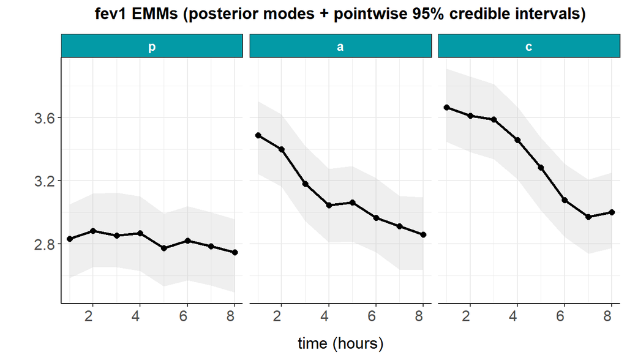

```r
# POSTERIORS OF EMMs
EMMs        <- chains[, grep("EMMs", names(chains))]
names(EMMs) <- paste0(datanew$drug, datanew$time)

# POSTERIOR MODES (approximate) + 95% CREDIBLE INTERVALS
EMMs_summary <- datanew %>%
  mutate(time_num = as.numeric(gsub("h", "", time)),
         mode     = apply(X = EMMs, MARGIN = 2, FUN = function(x) {
           d <- density(x = x, bw = "SJ")
           return(d$x[which.max(d$y)])
         }),
         lower    = apply(X = EMMs, MARGIN = 2, FUN = quantile, prob = 0.025),
         upper    = apply(X = EMMs, MARGIN = 2, FUN = quantile, prob = 0.975))

# EMMs PROFILES
ggplot(data = EMMs_summary, aes(x = time_num, y = mode)) +
  facet_wrap(~ drug) +
  geom_ribbon(aes(ymin = lower, ymax = upper), fill = "gray", alpha = 0.25) +
  geom_point(colour = "black", size = 2) +
  geom_line(colour = "black", size = 1) +
  xlab("time (hours)") +
  ylab("") +
  ggtitle("fev1 EMMs (posterior modes + pointwise 95% credible intervals)") +
  mytheme
```

# Case study conclusion

The main interest of the case study lies on how differences between treatment means change over time.

This can be done by pairwise comparisons of the EMMs.

For the sake of convenience, the stan output containing the posterior EMMs is first reformatted as follows:

```r
EMMs_wide <- EMMs %>%
  gather(key = condition, value = EMM) %>%
  mutate(drug = substr(condition, start = 1, stop = 1),
         time = substr(condition, start = 2, stop = nchar(condition))) %>%
  group_by(drug, time) %>%
  mutate(sample = 1:n()) %>%
  dplyr::select(-condition) %>%
  spread(key = drug, value = EMM)
```

The first few lines of ‘*EMMs_wide*’ are:

| time | sample | a | c | p |
| --- | --- | --- | --- | --- |
| 1h | 1 | 3.197841 | 3.606737 | 2.646195 |
| 1h | 2 | 3.531484 | 3.586191 | 2.807011 |
| 1h | 3 | 3.413758 | 3.566546 | 2.727466 |
| 1h | 4 | 3.231666 | 3.594123 | 2.648365 |
| 1h | 5 | 3.373219 | 3.596646 | 2.801359 |
| 1h | 6 | 3.349231 | 3.612894 | 2.629443 |

The posterior probability that drug A is superior to drug P at a given time (and for a given patient at a given baseline value) can be obtained from the joint posterior by comparing the EMM of drug A (column a) with the EMM of drug P (column p). $\Pr(C > P)$ and $\Pr(C > A)$ are obtained similarly.

```r
PoS <- EMMs_wide %>%
  group_by(time) %>%
  summarise(a_vs_p = mean(a > p),
            c_vs_p = mean(c > p),
            c_vs_a = mean(c > a)) %>%
  gather(key = comparison, value = proba, -time) %>%
  mutate(timen = as.numeric(gsub("h", "", time)))
```

These probabilities are depicted graphically below.

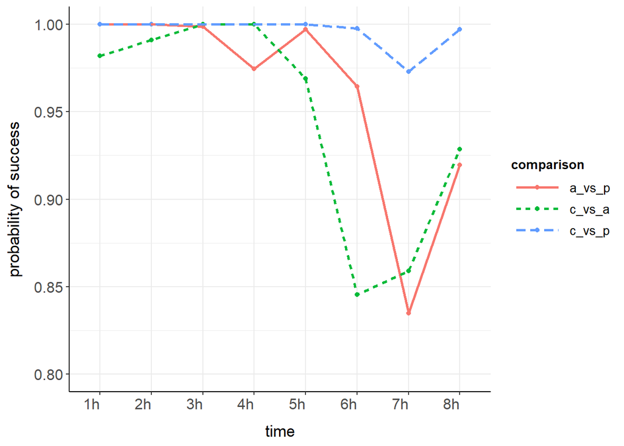

```r
ggplot(data = PoS, aes(x = time, y = proba)) +
  geom_point(aes(colour = comparison)) +
  geom_line(aes(x = timen, colour = comparison, linetype = comparison),
            size = 1) +
  scale_y_continuous(name = "probability of success", limits = c(0.80, 1)) +
  mytheme
```

# Prediction

Let’s, for the sake of illustration, predict the FEV1 profile for a future patient receiving drug A.

Predictions are more conveniently done outside the Stan model, by extracting the parameters from the posterior samples.

```r
# SEQUENCE OF POSTERIOR SAMPLES INDICES
iseq <- sample(x = 1:Nchains, size = 1e3, replace = TRUE)

fev1_new <- data.frame(t(sapply(X = iseq, FUN = function(i) {
  # ith POSTERIOR PARAMETERS
  beta     <- chains[i, grep("beta", names(chains))]
  sig_b    <- sqrt(chains[i, "sig2_b"])
  sig      <- sqrt(chains[i, "sig2"])
  rho      <- chains[i, "rho"]
  # PATIENT EFFECT
  b        <- rnorm(n = 1, mean = 0, sd = sig_b)
  # BASELINE VALUE (sampled from fitted beta distribution)
  basefev1 <- rbeta(n = 1, shape1 = 2, shape2 = 1.5) * (3.6 - 1.4) + 1.4
  # DATA (baseline, drug, and time) OF VIRTUAL PATIENT
  data_new <- data.frame(
    basefev1 = basefev1,
    drug     = relevel(factor("a", levels = c("p", "a", "c")), ref = "p"),
    time     = relevel(factor(paste0(1:8, "h")), ref = "1h"))
  # DESIGN MATRIX
  X_new    <- model.matrix(~ basefev1 + drug + time + time:drug,
                           data = data_new)
  # MEAN PROFILE
  eta      <- t(X_new %*% t(as.matrix(beta))) + b
  # AR(1) COVARIANCE MATRIX
  R        <- rho^abs(outer(1:8, 1:8, "-"))
  Sigma    <- diag(rep(sig, 8)) %*% R %*% diag(rep(sig, 8))
  # PREDICTED FEV1
  mvrnorm(n = 1, mu = eta, Sigma = Sigma)
})))

colnames(fev1_new) <- paste0("fev1", 1:8, "h")
```

In the figure below, the predicted profiles (in gray) are superimposed on the raw data (coloured), together with the predictive medians and pointwise 95% prediction intervals.

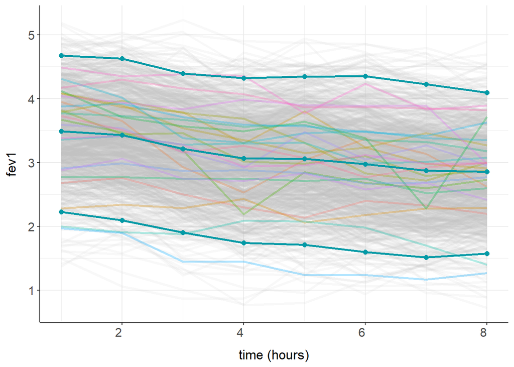

The joint probability, say, that a future FEV1 profile lies completely above 2 is

```r
mean(apply(X = fev1_new, MARGIN = 1, FUN = function(x) all(x > 2)))
```

```
## [1] 0.839
```

# References

Littell, Ramon C., George A. Milliken, Walter W. Stroup, Russell D. Wolfinger, and Olivier Schabenberger. 2006. *SAS for Mixed Models*. 2nd ed. SAS Institute.

Littell, Ramon C., Jane Pendergast, and Ranjini Natarajan. 2000. “Modelling Covariance Structure in the Analysis of Repeated Measures Data.” *Statistics in Medicine* 19 (13): 1793–1819.

Sutradhar, B. C., and P. Kumar. 2003. “The Inversion of Correlation Matrix for MA(1) Process.” *Applied Mathematics Letters* 16: 317–21.